# Modeling

2026-04-01

```r
#Pull data tables directly from statscan website
df_age <- get_cansim("35-10-006-01")
```

```
## Accessing CANSIM NDM product 35-10-0060 from Statistics Canada
```

```
## Parsing data
```

```r
#df_geo <- get_cansim("35-10-0156-01")
#df_total <-get_cansim("35-10-0068-01")
df_indID <- get_cansim("35-10-0125-01")
```

```
## Accessing CANSIM NDM product 35-10-0125 from Statistics Canada
## Parsing data
```

```r
#df_urb <-get_cansim("35-10-0127-01")
#df_pop  <- read_csv("df_pop1.csv", show_col_types = FALSE)
```

```r
#Filtering for "Number of homicide victims" in the "Statistics" column and Indigenous groups of interest from the "Indigenous Identity" column
#Filtering out "Non-Indigenous identity" and "Total, by Indigenous identity" from "Indigenous Identity" column
victims_indID <- df_indID %>%
  filter(str_detect(Statistics, "Number of homicide victims"),
         str_detect(`Indigenous Identity`, "First Nations|Métis|Inuk|Indigenous person"),
         `Indigenous Identity`!= "Non-Indigenous identity",
         `Indigenous Identity`!= "Total, by Indigenous identity") %>%
#Mutate unspecified Indigenous groups in one generalized group
  mutate(ind_type = case_when(
    `Indigenous Identity`=="Indigenous person, Indigenous group unknown"~"Indigenous identity", TRUE ~ `Indigenous Identity`))%>%
  select(year = REF_DATE, GEO, gender = Gender, ind_type, victims = VALUE)

#Remove "All genders" and "Gender unknown" from the "gender" column
df_ID<- victims_indID %>%
  filter(gender != "Gender unknown",
         gender !="All genders")

#aAd "Log_victims" column
df_ID$"Log_victims" <- log(df_ID$victims)

#Remove negative infinity after log transformation
df_ID <- filter(df_ID, Log_victims != "-Inf")

#Make "year" column date data
df_ID$year <- as.Date(df_ID$year, format = "%Y")

#Set Indigenous types as factors
df_ID$ind_type <- as.factor(df_ID$ind_type)
```

```r
#Filter for "Number of homicide victims" in `Victims and accused` column and "Indigenous identity" in the "Indigenous identity" column i
victims_age <- df_age %>%
  filter(str_detect(`Victims and accused`, "Number of homicide victims"),
         `Indigenous identity`== "Indigenous identity",) %>%
  select(year = REF_DATE, GEO = GEO, gender = Gender, ind_type = `Indigenous identity`, age =`Age group`, victims = VALUE) %>%
#Filter out NA's from "victims" column and unwanted categories from the "age" and "gender" columns
  filter(!is.na(victims),
  gender!="Gender unknown",
  age != "Age unknown",
  gender != "All genders",
  gender != "Unidentifiable human remains",
  age != "Total all ages")

#Add "Log_victims" column
victims_age$"Log_victims" <- log(victims_age$victims)

#Remove negative infinity
df_age <- filter(victims_age, Log_victims != "-Inf")

#Make "year" column date data
df_age$year <- as.Date(df_age$year, format = "%Y")
```

```r
#Review data characteristics and distribution for "victims" from df_ID
mean(df_ID$victims)
```

```
## [1] 22.34483
```

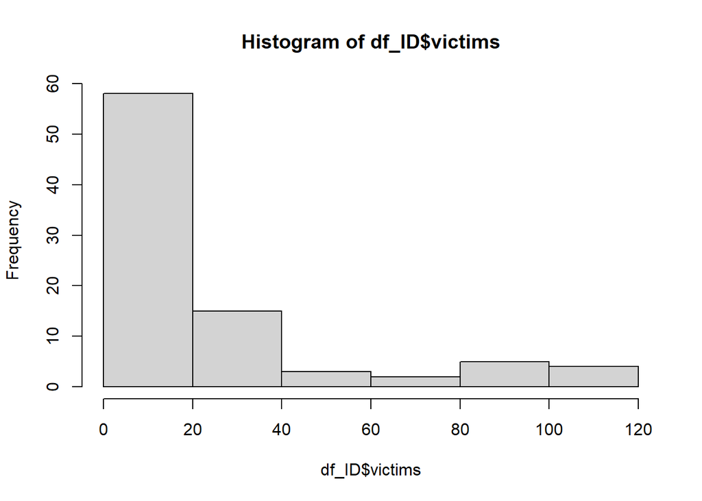

```r
hist(df_ID$victims)
```

```r
var(df_ID$victims)
```

```
## [1] 875.5541
```

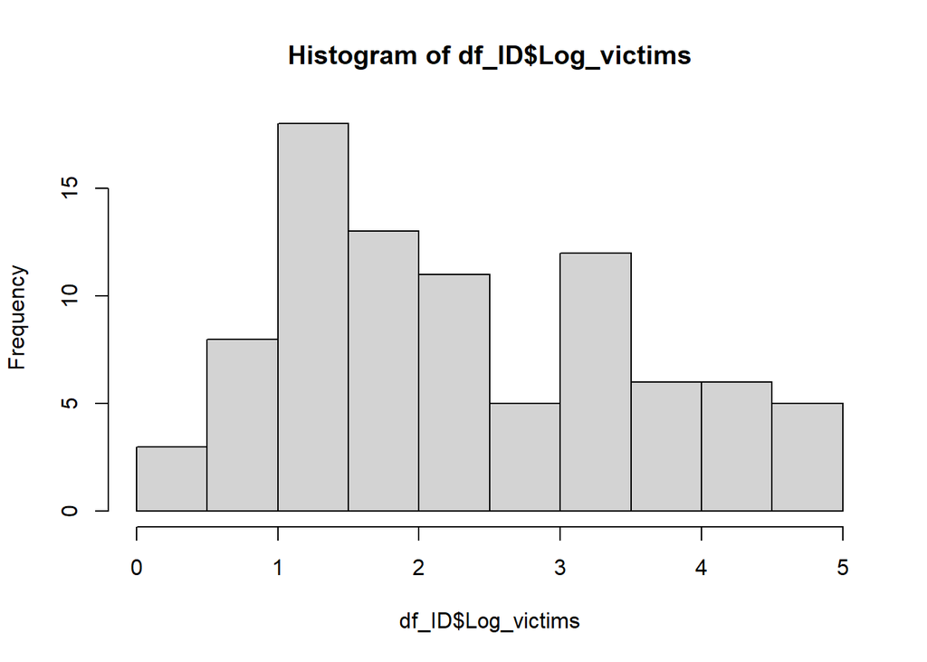

```r
# Checking distribution of "Log_victims" from df_ID
hist(df_ID$Log_victims)
```

```r
#Running Gaussian general linear model for "Log_victims" in df_ID for "year", "gender", "ind_type", and the interaction between "gender" and "ind_type"
model_ID_gaussian <- glm(Log_victims ~ year + gender * ind_type, data = df_ID, family = gaussian())
summary(model_ID_gaussian)
```

```
##
## Call:
## glm(formula = Log_victims ~ year + gender * ind_type, family = gaussian(),
##     data = df_ID)
##
## Coefficients:
##                                            Estimate Std. Error t value Pr(>|t|)
## (Intercept)                               1.732e+00  7.586e-01   2.283 0.025133
## year                                      1.545e-04  4.148e-05   3.725 0.000368
## genderFemale                             -1.063e+00  1.887e-01  -5.633  2.7e-07
## ind_typeIndigenous identity              -1.436e+00  1.887e-01  -7.612  5.3e-11
## ind_typeInuk (Inuit)                     -2.825e+00  1.887e-01 -14.975  < 2e-16
## ind_typeMétis                            -2.725e+00  1.887e-01 -14.444  < 2e-16
## genderFemale:ind_typeIndigenous identity -3.055e-02  2.702e-01  -0.113 0.910266
## genderFemale:ind_typeInuk (Inuit)         6.210e-01  2.668e-01   2.328 0.022519
## genderFemale:ind_typeMétis               -2.249e-02  2.668e-01  -0.084 0.933046
##
## (Intercept)                              *
## year                                     ***
## genderFemale                             ***
## ind_typeIndigenous identity              ***
## ind_typeInuk (Inuit)                     ***
## ind_typeMétis                            ***
## genderFemale:ind_typeIndigenous identity
## genderFemale:ind_typeInuk (Inuit)        *
## genderFemale:ind_typeMétis
## ---
## Signif. codes:  0 '***' 0.001 '**' 0.01 '*' 0.05 '.' 0.1 ' ' 1
##
## (Dispersion parameter for gaussian family taken to be 0.1957392)
##
##     Null deviance: 141.136  on 86  degrees of freedom
## Residual deviance:  15.268  on 78  degrees of freedom
## AIC: 115.5
##
## Number of Fisher Scoring iterations: 2
```

Residual deviance ratio: 0.108 (Low value suggests good fit) Calculated residual deviance: 0.196 (Values below 1 suggests under-dispersion) AIC: 115.5

```r
#Checking and plotting Pearson residuals and associated Quantile-Quantile (Q-Q) residuals
summary(residuals(model_ID_gaussian, type = "pearson"))
```

```
##     Min.  1st Qu.   Median     Mean  3rd Qu.     Max.
## -1.69706 -0.13820  0.04481  0.00000  0.18661  0.98774
```

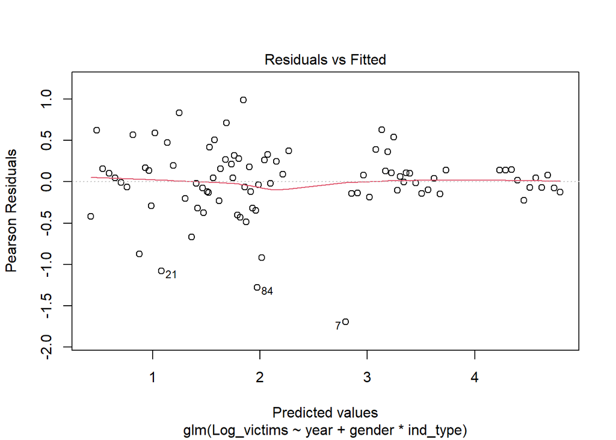

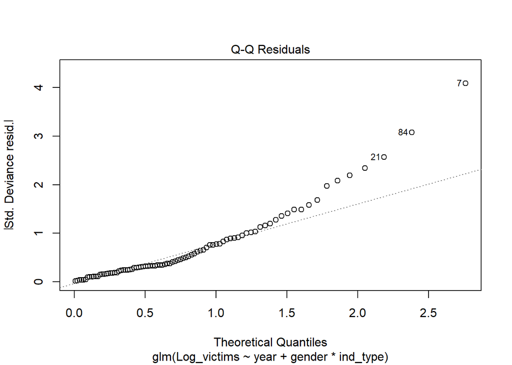

```r
plot(model_ID_gaussian, which = 1:2)
```

We use Pearson residuals to check the difference between observed and predicted values. This allows us to evaluate goodness-of-fit and check for outliers. With a residuals range from -1.70 to 0.99, the model is fairly symmetric around 0 (mean = 0.00000). This indicates a decent but not perfect goodness-of-fit. Observations 21, 84, and 7 stand out as possible outliers. Upon investigation, these observations do represent genuine observations with significantly lower victim counts then the average for the associated Indigenous group/gender interaction.The Q-Q residual plot shows deviation at the upper tail signifying the possible existence of over-dispersion.

```r
#Running Poisson general linear model for "victims" in df_ID for "year", "gender", "ind_type", and the interaction between "gender" and "ind_type"
model_ID_poisson <- glm(victims ~ year + gender * ind_type, data = df_ID, family = "poisson")
summary(model_ID_poisson)
```

```
##
## Call:
## glm(formula = victims ~ year + gender * ind_type, family = "poisson",
##     data = df_ID)
##
## Coefficients:
##                                            Estimate Std. Error z value Pr(>|z|)
## (Intercept)                               1.892e+00  3.630e-01   5.212 1.87e-07
## year                                      1.455e-04  1.988e-05   7.318 2.51e-13
## genderFemale                             -1.056e+00  6.179e-02 -17.093  < 2e-16
## ind_typeIndigenous identity              -1.263e+00  6.685e-02 -18.894  < 2e-16
## ind_typeInuk (Inuit)                     -2.748e+00  1.279e-01 -21.480  < 2e-16
## ind_typeMétis                            -2.605e+00  1.197e-01 -21.772  < 2e-16
## genderFemale:ind_typeIndigenous identity -1.377e-01  1.402e-01  -0.982  0.32618
## genderFemale:ind_typeInuk (Inuit)         6.660e-01  2.048e-01   3.252  0.00114
## genderFemale:ind_typeMétis               -8.326e-02  2.425e-01  -0.343  0.73137
##
## (Intercept)                              ***
## year                                     ***
## genderFemale                             ***
## ind_typeIndigenous identity              ***
## ind_typeInuk (Inuit)                     ***
## ind_typeMétis                            ***
## genderFemale:ind_typeIndigenous identity
## genderFemale:ind_typeInuk (Inuit)        **
## genderFemale:ind_typeMétis
## ---
## Signif. codes:  0 '***' 0.001 '**' 0.01 '*' 0.05 '.' 0.1 ' ' 1
##
## (Dispersion parameter for poisson family taken to be 1)
##
##     Null deviance: 2610.45  on 86  degrees of freedom
## Residual deviance:  111.47  on 78  degrees of freedom
## AIC: 493.43
##
## Number of Fisher Scoring iterations: 4
```

```r
#Checking and plotting Pearson residuals and associated Quantile-Quantile (Q-Q) residuals
summary(residuals(model_ID_poisson, type = "pearson"))
```

```
##      Min.   1st Qu.    Median      Mean   3rd Qu.      Max.
## -3.765716 -0.620829 -0.103097 -0.003098  0.616919  3.721696
```

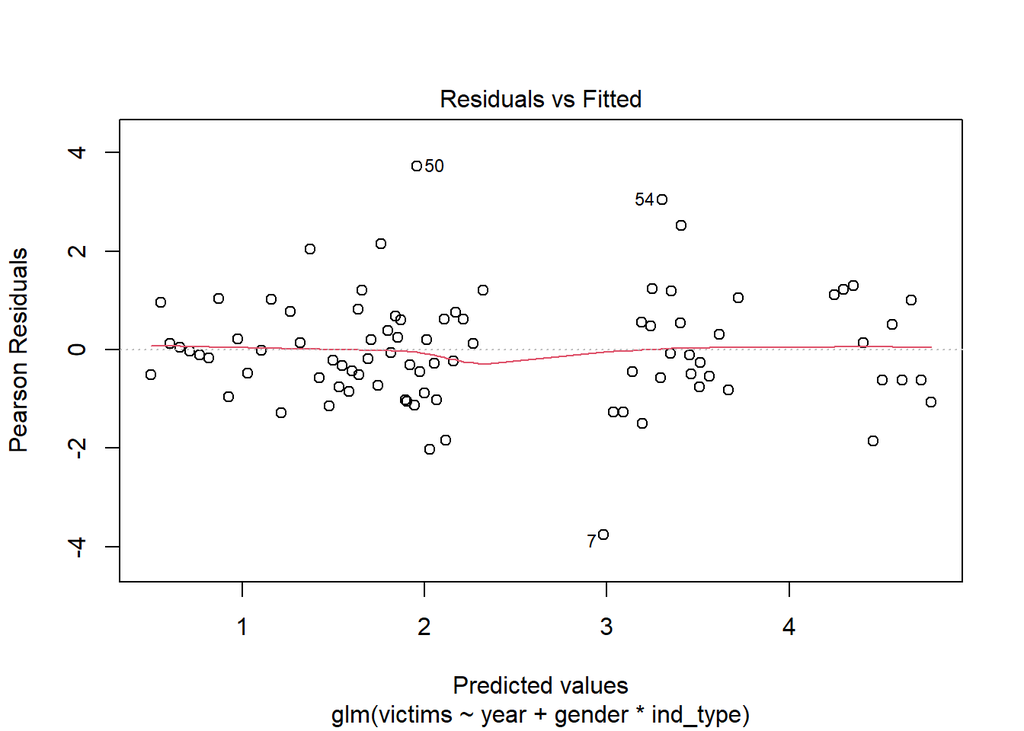

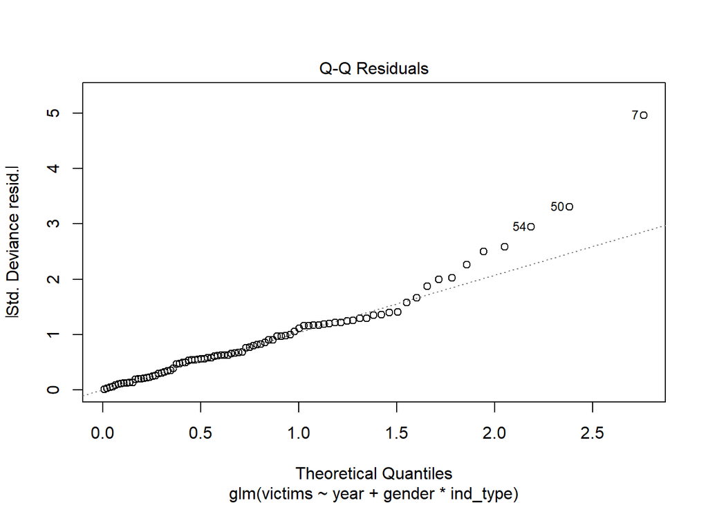

```r
plot(model_ID_poisson, which = 1:2)
```

```r
#Checking and plotting Deviance residuals and associated Quantile-Quantile (Q-Q) residuals
summary(residuals(model_ID_poisson, type = "deviance"))
```

```
##     Min.  1st Qu.   Median     Mean  3rd Qu.     Max.
## -4.70629 -0.62757 -0.10434 -0.06757  0.59705  3.14859
```

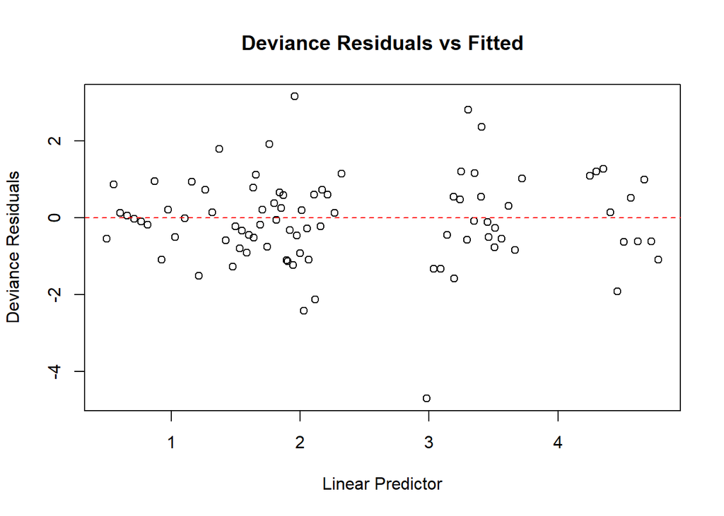

```r
dev_resid <- residuals(model_ID_poisson, type = "deviance")
plot(predict(model_ID_poisson, type = "link"), dev_resid,
     xlab = "Linear Predictor", ylab = "Deviance Residuals",
     main = "Deviance Residuals vs Fitted")
abline(h = 0, lty = 2, col = "red")
```

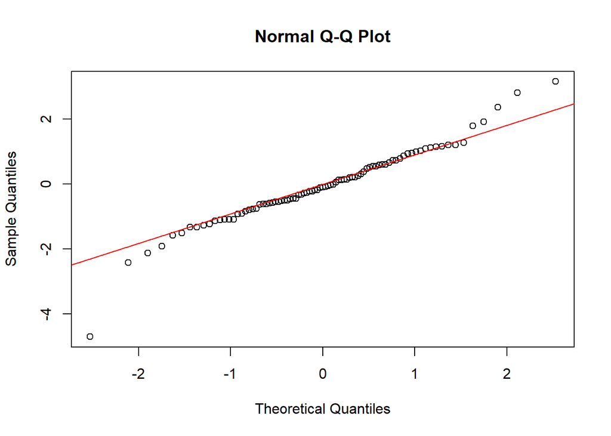

```r
qqnorm(dev_resid)
qqline(dev_resid, col = "red")
```

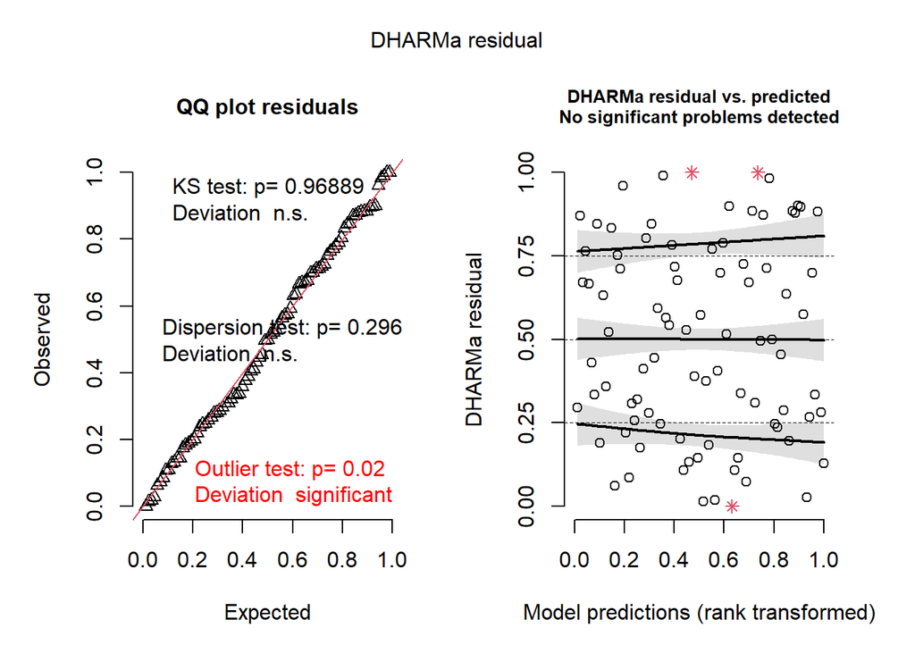

```r
#Plotting DHARMa Quantile residuals
plot(simulateResiduals(model_ID_poisson))
```

The Pearson residuals for the Poisson model suggest a decent goodness-of-fit, with a mean and median very close to 0 and a range with approximately symmetric tails (-3.77 to 3.72). However, as Pearson residuals typically fall within a ±2–3 range, a range of -3.77 to 3.72 would suggest possible outliers or over-dispersion (though over-dispersion is common in real count data). The Pearson residuals plot highlights observations 50, 54, and 7 as possible outliers. The Q-Q residual plot shows significant deviation at the upper tail also signifying the possible existence of over-dispersion.

Deviance residuals centered around 0 also suggest a decent goodness-of-fit. However, we also have a fairly wide range (-4.7, 3.15) suggesting over-dispersion.The associated Q-Q residuals also show a deviation from the predictions at the upper and lower tail, providing further evidence of over-dispersion.

Overall, the Poisson model is acceptable for the purposes of this study but do demonstrate the existence of some significant outliers which may skew results.

```r
#Running Negative Binomial general linear model for "victims" in df_ID for "year", "gender", "ind_type", and the interaction between "gender" and "ind_type"
model_ID_nb <- glm.nb(victims ~ year+ gender * ind_type, data = df_ID)
summary(model_ID_nb)
```

```
##
## Call:
## glm.nb(formula = victims ~ year + gender * ind_type, data = df_ID,
##     init.theta = 109.6341549, link = log)
##
## Coefficients:
##                                            Estimate Std. Error z value Pr(>|z|)
## (Intercept)                               1.732e+00  4.381e-01   3.952 7.75e-05
## year                                      1.546e-04  2.407e-05   6.420 1.36e-10
## genderFemale                             -1.061e+00  7.420e-02 -14.295  < 2e-16
## ind_typeIndigenous identity              -1.275e+00  7.863e-02 -16.211  < 2e-16
## ind_typeInuk (Inuit)                     -2.752e+00  1.343e-01 -20.487  < 2e-16
## ind_typeMétis                            -2.610e+00  1.265e-01 -20.627  < 2e-16
## genderFemale:ind_typeIndigenous identity -1.299e-01  1.522e-01  -0.853  0.39361
## genderFemale:ind_typeInuk (Inuit)         6.694e-01  2.128e-01   3.146  0.00166
## genderFemale:ind_typeMétis               -7.852e-02  2.494e-01  -0.315  0.75289
##
## (Intercept)                              ***
## year                                     ***
## genderFemale                             ***
## ind_typeIndigenous identity              ***
## ind_typeInuk (Inuit)                     ***
## ind_typeMétis                            ***
## genderFemale:ind_typeIndigenous identity
## genderFemale:ind_typeInuk (Inuit)        **
## genderFemale:ind_typeMétis
## ---
## Signif. codes:  0 '***' 0.001 '**' 0.01 '*' 0.05 '.' 0.1 ' ' 1
##
## (Dispersion parameter for Negative Binomial(109.6342) family taken to be 1)
##
##     Null deviance: 2097.377  on 86  degrees of freedom
## Residual deviance:   95.524  on 78  degrees of freedom
## AIC: 493.87
##
## Number of Fisher Scoring iterations: 1
##
##
##               Theta:  110
##           Std. Err.:  110
##
##  2 x log-likelihood:  -473.865
```

Residual deviance ratio: 0.0456 (Low value suggests good fit) Calculated residual deviance: 1.225 (Value above 1 suggests possible over-dispersion) AIC: 493.87

```r
#Checking and plotting Pearson residuals and associated Quantile-Quantile (Q-Q) residuals
summary(residuals(model_ID_nb, type = "pearson"))
```

```
##      Min.   1st Qu.    Median      Mean   3rd Qu.      Max.
## -3.415019 -0.555642 -0.094562 -0.001391  0.595349  3.599625
```

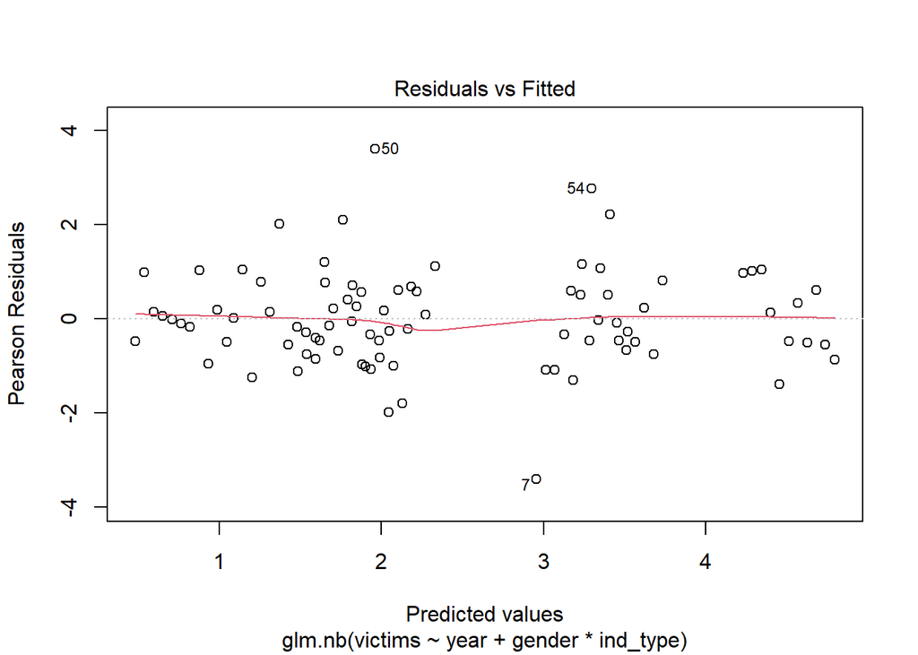

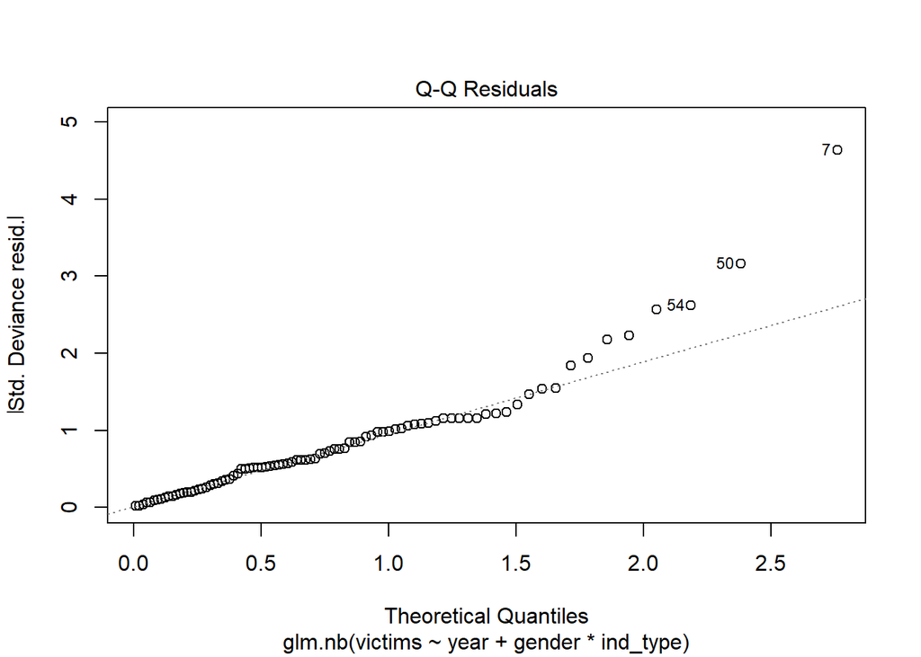

```r
plot(model_ID_nb, which = 1:2)
```

```r
#Checking and plotting Deviance residuals and associated Quantile-Quantile (Q-Q) residuals
summary(residuals(model_ID_nb, type = "deviance"))
```

```
##     Min.  1st Qu.   Median     Mean  3rd Qu.     Max.
## -4.38104 -0.57638 -0.09493 -0.06824  0.57730  3.01081
```

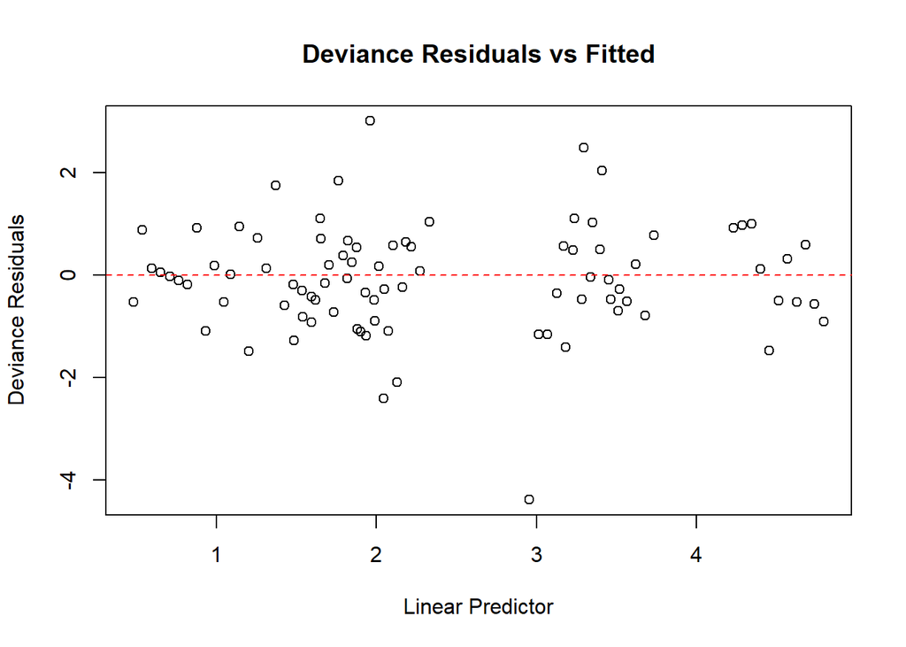

```r
dev_resid <- residuals(model_ID_nb, type = "deviance")
plot(predict(model_ID_nb, type = "link"), dev_resid,
     xlab = "Linear Predictor", ylab = "Deviance Residuals",
     main = "Deviance Residuals vs Fitted")
abline(h = 0, lty = 2, col = "red")
```

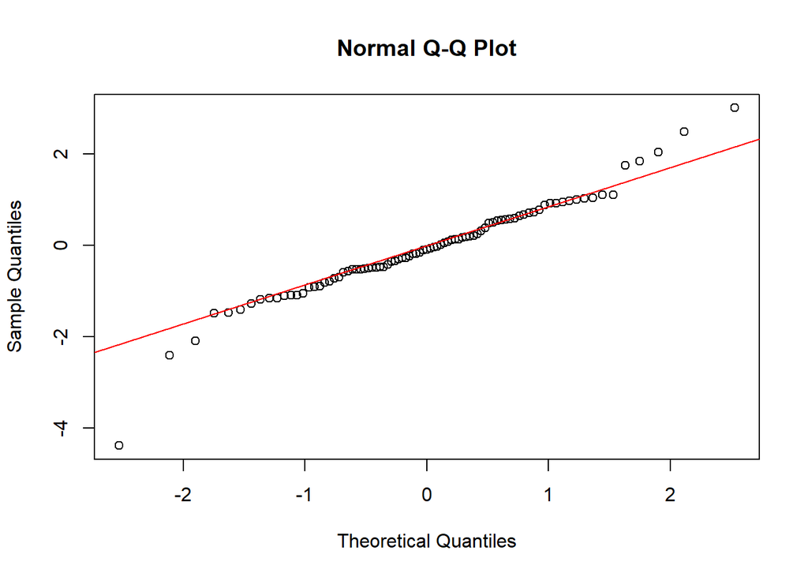

```r
qqnorm(dev_resid)
qqline(dev_resid, col = "red")
```

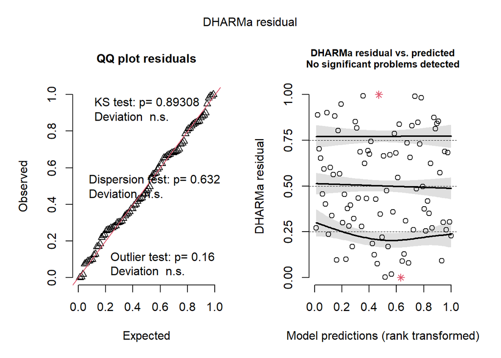

```r
#Plotting DHARMa Quantile residuals
plot(simulateResiduals(model_ID_nb))
```

Pearson residuals suggest decent goodness-of-fit, with a mean and median close to zero and fairly symmetrical 1st and 3rd quartiles (-0.556 vs 0.595). A residual range of (-3.4 to 3.6), being beyond the standard ±3 for Negative Binomial models, once again points to the existence of outliers. This is further evidenced by the deviation found at the upper quartile of the Q-Q residuals plot.

The DHARMa Quantile residuals suggest an overall acceptable goodness-of-fit without significant deviations, as the KS test had a value of p = 0.893, well above the (P>0.005) significance. With a dispersion test score above (P>0.05) at (p = 0.632), no significant dispersion was found in the model. This suggests the the Negative Binomial model successfully accounts for any over-dispersion. The outlier test (p = 0.16) also falls above the (P>0.05) significance score, suggesting that no significant outliers were found in the model.

The theta value (110) and an identical associated standard error value (110) indicates that the data is very close to a Poisson distribution and may be exhibiting under-dispersion. This suggests that the Poisson model may fit the data best.

Even though the AIC value for the NB model is higher then the Poisson model by 0.44, however, if AIC values are within 2 units of each other they are considered to have approximately the same performance.

```r
#Running ANOVA test for each df_ID model
anova(model_ID_gaussian)
```

```
## Analysis of Deviance Table
##
## Model: gaussian, link: identity
##
## Response: Log_victims
##
## Terms added sequentially (first to last)
##
##
##                 Df Deviance Resid. Df Resid. Dev        F    Pr(>F)
## NULL                               86    141.136
## year             1    2.542        85    138.595  12.9842 0.0005511 ***
## gender           1   18.559        84    120.036  94.8126 4.043e-15 ***
## ind_type         3  103.091        81     16.945 175.5584 < 2.2e-16 ***
## gender:ind_type  3    1.677        78     15.268   2.8565 0.0423966 *
## ---
## Signif. codes:  0 '***' 0.001 '**' 0.01 '*' 0.05 '.' 0.1 ' ' 1
```

```r
anova(model_ID_poisson)
```

```
## Analysis of Deviance Table
##
## Model: poisson, link: log
##
## Response: victims
##
## Terms added sequentially (first to last)
##
##
##                 Df Deviance Resid. Df Resid. Dev  Pr(>Chi)
## NULL                               86    2610.45
## year             1    47.22        85    2563.23 6.337e-12 ***
## gender           1   457.81        84    2105.42 < 2.2e-16 ***
## ind_type         3  1981.69        81     123.72 < 2.2e-16 ***
## gender:ind_type  3    12.25        78     111.47  0.006568 **
## ---
## Signif. codes:  0 '***' 0.001 '**' 0.01 '*' 0.05 '.' 0.1 ' ' 1
```

```r
anova(model_ID_nb)
```

```
## Analysis of Deviance Table
##
## Model: Negative Binomial(109.6342), link: log
##
## Response: victims
##
## Terms added sequentially (first to last)
##
##
##                 Df Deviance Resid. Df Resid. Dev  Pr(>Chi)
## NULL                               86    2097.38
## year             1    39.28        85    2058.10 3.669e-10 ***
## gender           1   382.19        84    1675.90 < 2.2e-16 ***
## ind_type         3  1568.78        81     107.13 < 2.2e-16 ***
## gender:ind_type  3    11.60        78      95.52  0.008876 **
## ---
## Signif. codes:  0 '***' 0.001 '**' 0.01 '*' 0.05 '.' 0.1 ' ' 1
```

Results:

All models suggest that year, gender, and indigenous identity significantly predict victim counts as all terms were found to be statistically significant (p < 0.001) in each model. The interaction between gender and indigenous identity was also found to be statistically significant.

The residual deviance of the Gaussian model (residual deviance = 15.27 on 78 degrees of freedom) indicates under-dispersion which violates the Gaussian assumption of constant variance. While all terms and the interaction term of the Gaussian model were found to be significant, the log transformation did not fully correct the distributional problems inherent to count data.

Inversely, the residual deviance of the Poisson model (residual deviance = 111 on 78 degrees of freedom) indicates significant over-dispersion which violates the Poisson assumption that mean and variance are equal. The data used in this model contains more variability then Poisson allows. Over-dispersion of any magnitude leads to underestimated standard errors and artificially small p-values. This means that even though the Poisson model found all terms and the interaction to be statistically significant, it is likely that the significance if being inflated due to over-dispersion.

All three models suggest that there is a significant interaction between gender and Indigenous identity regarding homicide victimization. For the Negative Binomial model, the interaction between gender and ind_type has a statistically significant p-value (p = 0.008876). It was found that males experience higher rates of victimization across all Indigenous identities. However, the discrepancy between male and female victimization was smaller among Inuit people specifically, when compared to the reference group (Male/Fist Nations). This key difference is likely the primary factor behind this statistically significant relationship.

Gaussian Model: F scores above 1 demonstrate that the group means differ, with higher values indicating stronger differences.

```r
model_ID_gaussian2 <- aov(Log_victims ~ gender * ind_type, data = df_ID)
tukey_ID_gaussian <- TukeyHSD(model_ID_gaussian2)
print(tukey_ID_gaussian)
```

```
##   Tukey multiple comparisons of means
##     95% family-wise confidence level
##
## Fit: aov(formula = Log_victims ~ gender * ind_type, data = df_ID)
##
## $gender
##                   diff       lwr        upr p adj
## Female-Male -0.9172852 -1.120928 -0.7136428     0
##
## $ind_type
##                                                                 diff        lwr
## Indigenous identity-First Nations (North American Indian) -1.4336000 -1.8156227
## Inuk (Inuit)-First Nations (North American Indian)        -2.5145874 -2.8921419
## Métis-First Nations (North American Indian)               -2.7360793 -3.1136337
## Inuk (Inuit)-Indigenous identity                          -1.0809874 -1.4630101
## Métis-Indigenous identity                                 -1.3024793 -1.6845020
## Métis-Inuk (Inuit)                                        -0.2214919 -0.5990463
##                                                                  upr     p adj
## Indigenous identity-First Nations (North American Indian) -1.0515773 0.0000000
## Inuk (Inuit)-First Nations (North American Indian)        -2.1370330 0.0000000
## Métis-First Nations (North American Indian)               -2.3585248 0.0000000
## Inuk (Inuit)-Indigenous identity                          -0.6989647 0.0000000
## Métis-Indigenous identity                                 -0.9204565 0.0000000
## Métis-Inuk (Inuit)                                         0.1560626 0.4190067
##
## $`gender:ind_type`
##                                                                                               diff
## Female:First Nations (North American Indian)-Male:First Nations (North American Indian) -1.0626354
## Male:Indigenous identity-Male:First Nations (North American Indian)                     -1.4359497
## Female:Indigenous identity-Male:First Nations (North American Indian)                   -2.5009183
## Male:Inuk (Inuit)-Male:First Nations (North American Indian)                            -2.8250993
## Female:Inuk (Inuit)-Male:First Nations (North American Indian)                          -3.2667109
## Male:Métis-Male:First Nations (North American Indian)                                   -2.7248361
## Female:Métis-Male:First Nations (North American Indian)                                 -3.8099579
## Male:Indigenous identity-Female:First Nations (North American Indian)                   -0.3733143
## Female:Indigenous identity-Female:First Nations (North American Indian)                 -1.4382830
## Male:Inuk (Inuit)-Female:First Nations (North American Indian)                          -1.7624639
## Female:Inuk (Inuit)-Female:First Nations (North American Indian)                        -2.2040756
## Male:Métis-Female:First Nations (North American Indian)                                 -1.6622007
## Female:Métis-Female:First Nations (North American Indian)                               -2.7473225
```

[output cut: 87 more lines]

```
## Female:Indigenous identity-Male:Indigenous identity                                     0.0000585
## Male:Inuk (Inuit)-Male:Indigenous identity                                              0.0000000
## Female:Inuk (Inuit)-Male:Indigenous identity                                            0.0000000
## Male:Métis-Male:Indigenous identity                                                     0.0000004
## Female:Métis-Male:Indigenous identity                                                   0.0000000
## Male:Inuk (Inuit)-Female:Indigenous identity                                            0.7749322
## Female:Inuk (Inuit)-Female:Indigenous identity                                          0.0098237
## Male:Métis-Female:Indigenous identity                                                   0.9603416
## Female:Métis-Female:Indigenous identity                                                 0.0000005
## Female:Inuk (Inuit)-Male:Inuk (Inuit)                                                   0.3804677
## Male:Métis-Male:Inuk (Inuit)                                                            0.9996654
## Female:Métis-Male:Inuk (Inuit)                                                          0.0001647
## Male:Métis-Female:Inuk (Inuit)                                                          0.1495523
## Female:Métis-Female:Inuk (Inuit)                                                        0.1473531
## Female:Métis-Male:Métis                                                                 0.0000239
```

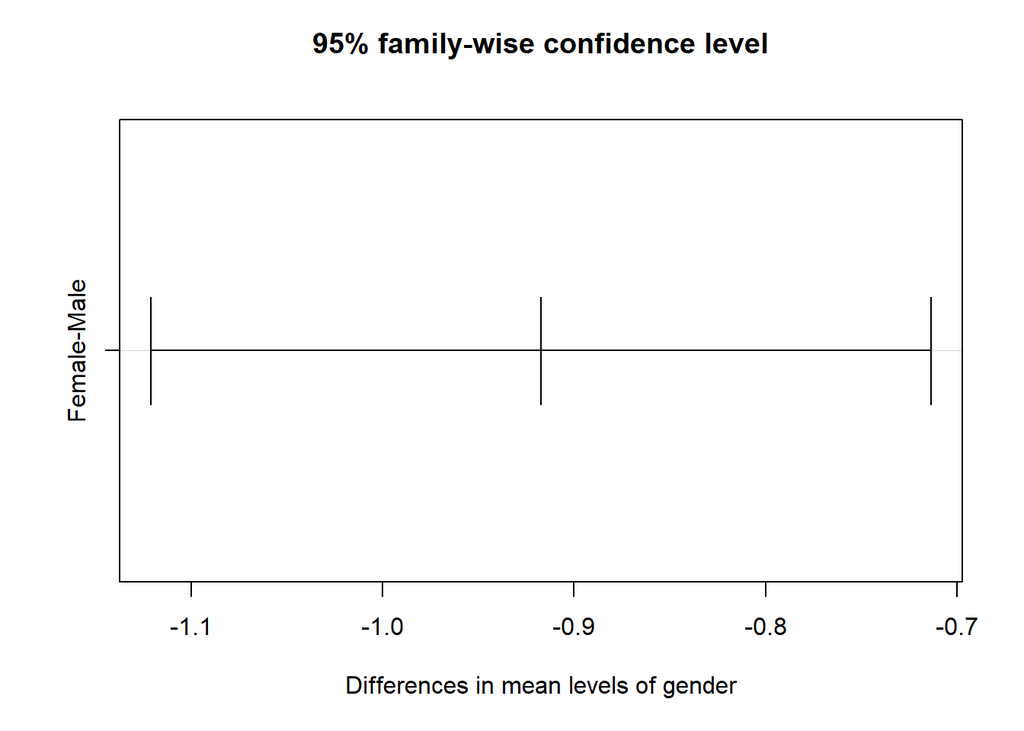

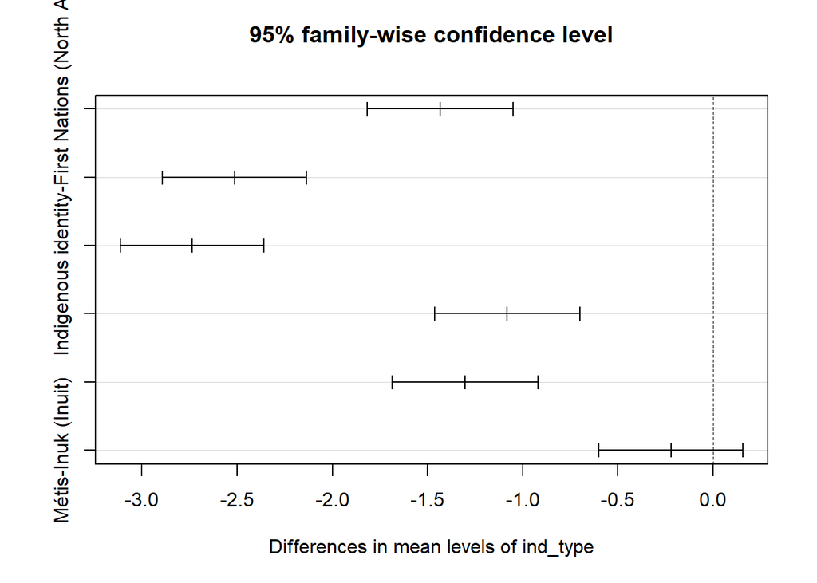

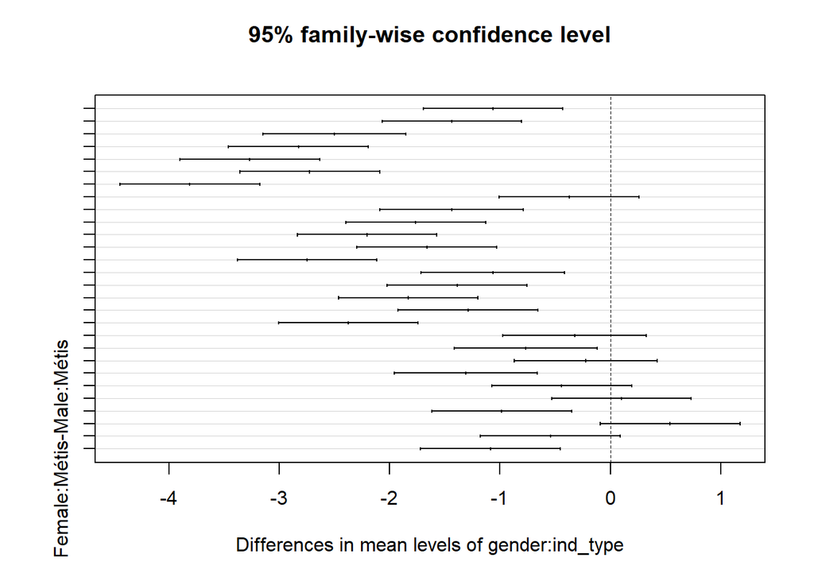

```r
plot(tukey_ID_gaussian)
```

Results:

Among the Indigenous groups, Métis and Inuk/Inuit were statistically similar to each other but both substantially lower than First Nations and ‘Indigenous identity’. First Nations (North American Indian) is the reference group or baseline (highest mean).Indigenous identity, Inuk (Inuit), and Métis all have significantly lower means than First Nations (all p adj values equal to 0.0000000 indicates large negative differences). Métis vs Inuk (Inuit) scores (difference = -0.22, CI crosses 0, p adj = 0.419) suggest no significant difference.

Mean Log_victims differed significantly by gender and by Indigenous identity group. The gender gap itself depended on the Indigenous identity group (interaction p = 0.042). Overall, females had lower Log_victims than males by approximately 0.92 units (95 % family-wise CI: –1.12 to –0.71). The entire confidence interval is negative and well below 0 indicating that a very strong difference exists.This is the overall (marginal) gender effect, averaging across all ind_type levels.

The generalized Indigenous identity group also had a mean group difference of -1.06 and an adjusted p value of 0.00006. suggesting that females have significantly lower Log_victims than males. The Inuk(Inuit) group did not show a significant difference between males and females with an adjust p value of 0.38 being above our 0.05 significance threshold. While a moderate negative difference does seem to exist between males and females in this group, the CI interval crosses 0 indicating that the difference is not significant.

Métis group mean difference of -1.085 and an adjusted p values of 0.00003, suggests that females were once again found to have a significantly lower Log_victim counts then the males.

In comparison to First Nations males (reference group) Inuk and Métis males has significantly lower Log_victim counts. Likewise, compared to First Nations females, Inuk, Métis, and Indigenous identity females had significantly lower Log_victim counts as well. The largest difference existing between the reference group (First Nations males) and Métis females (group with the lowest Log_victims count), demonstrating a very large negative difference.

All CIs are family-wise and are therefore deliberately wider than ordinary 95 % CIs so the whole set of comparisons stays at 5 % error rate.

```r
model_ID_poisson2 <- aov(victims ~ gender * ind_type, data = df_ID)
tukey_ID_poisson <- TukeyHSD(model_ID_poisson2)
print(tukey_ID_poisson)
```

```
##   Tukey multiple comparisons of means
##     95% family-wise confidence level
##
## Fit: aov(formula = victims ~ gender * ind_type, data = df_ID)
##
## $gender
##                  diff       lwr       upr p adj
## Female-Male -21.09831 -24.31364 -17.88298     0
##
## $ind_type
##                                                                  diff
## Indigenous identity-First Nations (North American Indian) -45.1603493
## Inuk (Inuit)-First Nations (North American Indian)        -57.2272727
## Métis-First Nations (North American Indian)               -57.6818182
## Inuk (Inuit)-Indigenous identity                          -12.0669234
## Métis-Indigenous identity                                 -12.5214688
## Métis-Inuk (Inuit)                                         -0.4545455
##                                                                  lwr        upr
## Indigenous identity-First Nations (North American Indian) -51.192136 -39.128563
## Inuk (Inuit)-First Nations (North American Indian)        -63.188509 -51.266036
## Métis-First Nations (North American Indian)               -63.643055 -51.720581
## Inuk (Inuit)-Indigenous identity                          -18.098710  -6.035137
## Métis-Indigenous identity                                 -18.553255  -6.489682
## Métis-Inuk (Inuit)                                         -6.415782   5.506691
##                                                               p adj
## Indigenous identity-First Nations (North American Indian) 0.0000000
## Inuk (Inuit)-First Nations (North American Indian)        0.0000000
## Métis-First Nations (North American Indian)               0.0000000
## Inuk (Inuit)-Indigenous identity                          0.0000074
## Métis-Indigenous identity                                 0.0000033
## Métis-Inuk (Inuit)                                        0.9971389
##
## $`gender:ind_type`
##                                                                                                diff
## Female:First Nations (North American Indian)-Male:First Nations (North American Indian) -60.1818182
## Male:Indigenous identity-Male:First Nations (North American Indian)                     -66.1818182
## Female:Indigenous identity-Male:First Nations (North American Indian)                   -84.1727273
## Male:Inuk (Inuit)-Male:First Nations (North American Indian)                            -86.3636364
## Female:Inuk (Inuit)-Male:First Nations (North American Indian)                          -88.2727273
## Male:Métis-Male:First Nations (North American Indian)                                   -85.4545455
```

[output cut: 94 more lines]

```
## Female:Indigenous identity-Male:Indigenous identity                                     0.0000140
## Male:Inuk (Inuit)-Male:Indigenous identity                                              0.0000005
## Female:Inuk (Inuit)-Male:Indigenous identity                                            0.0000000
## Male:Métis-Male:Indigenous identity                                                     0.0000015
## Female:Métis-Male:Indigenous identity                                                   0.0000000
## Male:Inuk (Inuit)-Female:Indigenous identity                                            0.9976481
## Female:Inuk (Inuit)-Female:Indigenous identity                                          0.9153921
## Male:Métis-Female:Indigenous identity                                                   0.9999309
## Female:Métis-Female:Indigenous identity                                                 0.6232449
## Female:Inuk (Inuit)-Male:Inuk (Inuit)                                                   0.9988601
## Male:Métis-Male:Inuk (Inuit)                                                            0.9999922
## Female:Métis-Male:Inuk (Inuit)                                                          0.9405943
## Male:Métis-Female:Inuk (Inuit)                                                          0.9872814
## Female:Métis-Female:Inuk (Inuit)                                                        0.9991692
## Female:Métis-Male:Métis                                                                 0.8340883
```

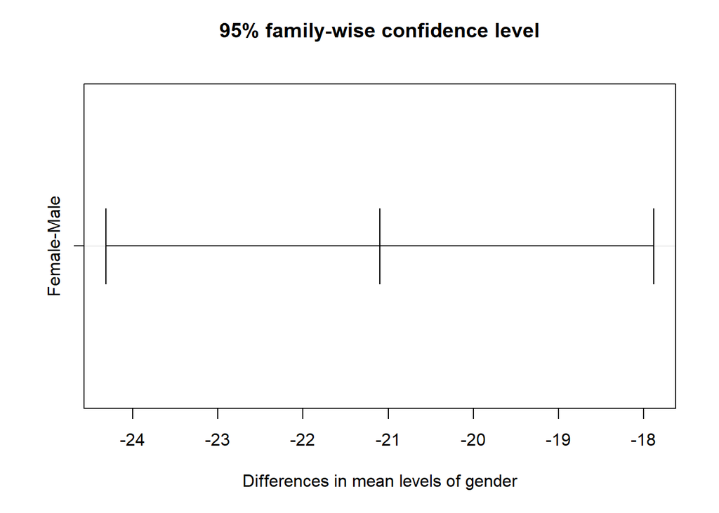

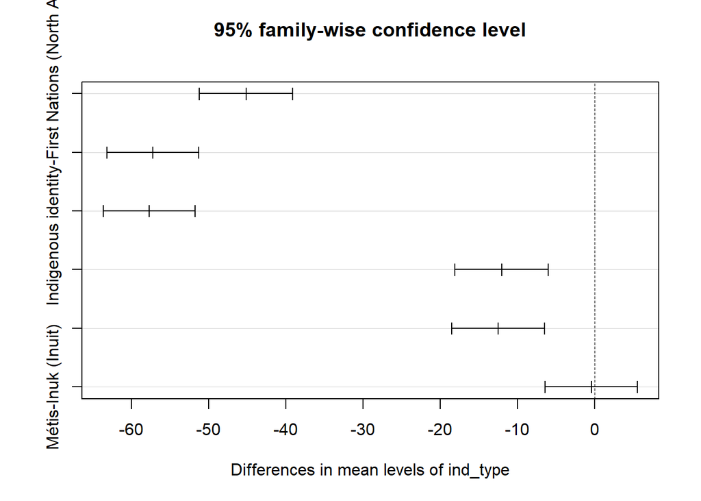

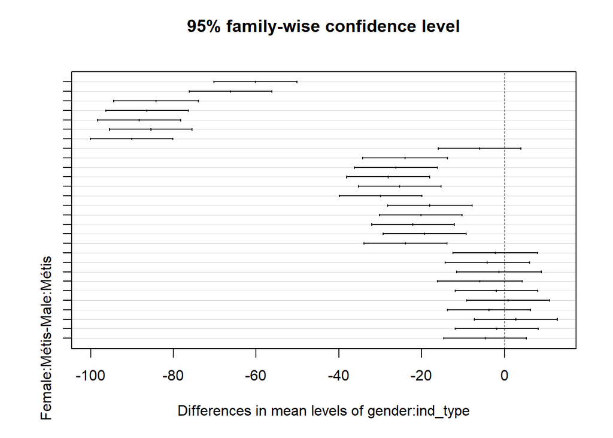

```r
plot(tukey_ID_poisson)
```

First Nations were demonstrated to have significantly higher victim counts compared to all other Indigenous groups analyzed. With a mean group difference of -57.68 between Métis and First Nations, -57.23 between Inuk and First Nations, and -45.16 between Indigenous identity and First Nations indicate a large negative differences between all other groups and First Nations. Furthermore, the adjusted p value of 0 between First Nations and the other groups suggest highly significant differences.With a CI that crosses the 0 and an adjusted p value above the 0.05 significance threshold at 0.997, there was no significant difference found between Inuk and Métis groups. There was a significant difference found between Indigenous identity and both Inuk and Métis. Both Inuk and Métis having an approximate group mean difference of -12 compared to Indigenous identity, and adjusted p values of of 0.000007 between Inuk and Indigenous identity, and 0.000003 between Métis and Indigenous identity.

Large significant negative differences were found when comparing most groups against the reference group (Male:First Nations). With mean group differences ranging from -60 to -90 and an adjusted p value of 0 between Male:First Nations and all other groups. The interaction suggests the gender effect is not uniform across Indigenous groups (ind_type). The gap between males and females (pattern of differences) depends on the indigenous category.

```r
model_ID_nb2 <- aov(victims ~ gender * ind_type, data = df_ID)
tukey_ID_nb <- TukeyHSD(model_ID_nb2)
print(tukey_ID_nb)
```

```
##   Tukey multiple comparisons of means
##     95% family-wise confidence level
##
## Fit: aov(formula = victims ~ gender * ind_type, data = df_ID)
##
## $gender
##                  diff       lwr       upr p adj
## Female-Male -21.09831 -24.31364 -17.88298     0
##
## $ind_type
##                                                                  diff
## Indigenous identity-First Nations (North American Indian) -45.1603493
## Inuk (Inuit)-First Nations (North American Indian)        -57.2272727
## Métis-First Nations (North American Indian)               -57.6818182
## Inuk (Inuit)-Indigenous identity                          -12.0669234
## Métis-Indigenous identity                                 -12.5214688
## Métis-Inuk (Inuit)                                         -0.4545455
##                                                                  lwr        upr
## Indigenous identity-First Nations (North American Indian) -51.192136 -39.128563
## Inuk (Inuit)-First Nations (North American Indian)        -63.188509 -51.266036
## Métis-First Nations (North American Indian)               -63.643055 -51.720581
## Inuk (Inuit)-Indigenous identity                          -18.098710  -6.035137
## Métis-Indigenous identity                                 -18.553255  -6.489682
## Métis-Inuk (Inuit)                                         -6.415782   5.506691
##                                                               p adj
## Indigenous identity-First Nations (North American Indian) 0.0000000
## Inuk (Inuit)-First Nations (North American Indian)        0.0000000
## Métis-First Nations (North American Indian)               0.0000000
## Inuk (Inuit)-Indigenous identity                          0.0000074
## Métis-Indigenous identity                                 0.0000033
## Métis-Inuk (Inuit)                                        0.9971389
##
## $`gender:ind_type`
##                                                                                                diff
## Female:First Nations (North American Indian)-Male:First Nations (North American Indian) -60.1818182
## Male:Indigenous identity-Male:First Nations (North American Indian)                     -66.1818182
## Female:Indigenous identity-Male:First Nations (North American Indian)                   -84.1727273
## Male:Inuk (Inuit)-Male:First Nations (North American Indian)                            -86.3636364
## Female:Inuk (Inuit)-Male:First Nations (North American Indian)                          -88.2727273
## Male:Métis-Male:First Nations (North American Indian)                                   -85.4545455
```

[output cut: 94 more lines]

```
## Female:Indigenous identity-Male:Indigenous identity                                     0.0000140
## Male:Inuk (Inuit)-Male:Indigenous identity                                              0.0000005
## Female:Inuk (Inuit)-Male:Indigenous identity                                            0.0000000
## Male:Métis-Male:Indigenous identity                                                     0.0000015
## Female:Métis-Male:Indigenous identity                                                   0.0000000
## Male:Inuk (Inuit)-Female:Indigenous identity                                            0.9976481
## Female:Inuk (Inuit)-Female:Indigenous identity                                          0.9153921
## Male:Métis-Female:Indigenous identity                                                   0.9999309
## Female:Métis-Female:Indigenous identity                                                 0.6232449
## Female:Inuk (Inuit)-Male:Inuk (Inuit)                                                   0.9988601
## Male:Métis-Male:Inuk (Inuit)                                                            0.9999922
## Female:Métis-Male:Inuk (Inuit)                                                          0.9405943
## Male:Métis-Female:Inuk (Inuit)                                                          0.9872814
## Female:Métis-Female:Inuk (Inuit)                                                        0.9991692
## Female:Métis-Male:Métis                                                                 0.8340883
```

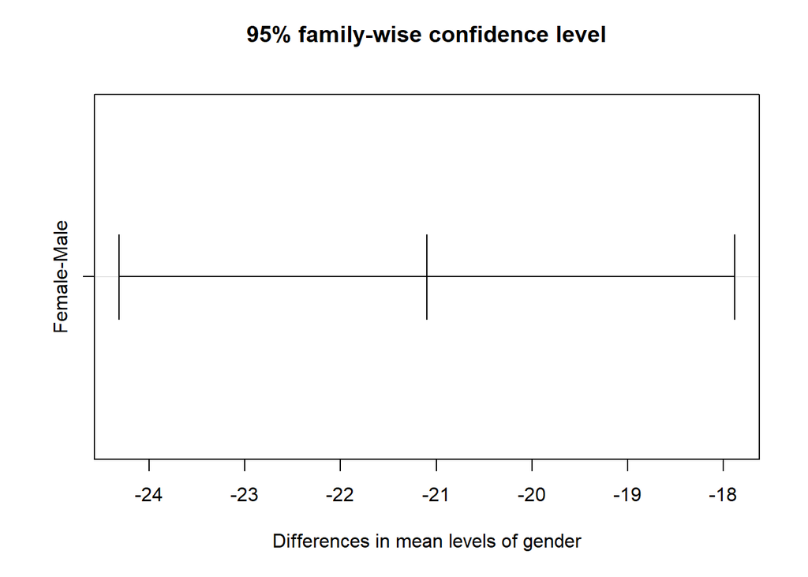

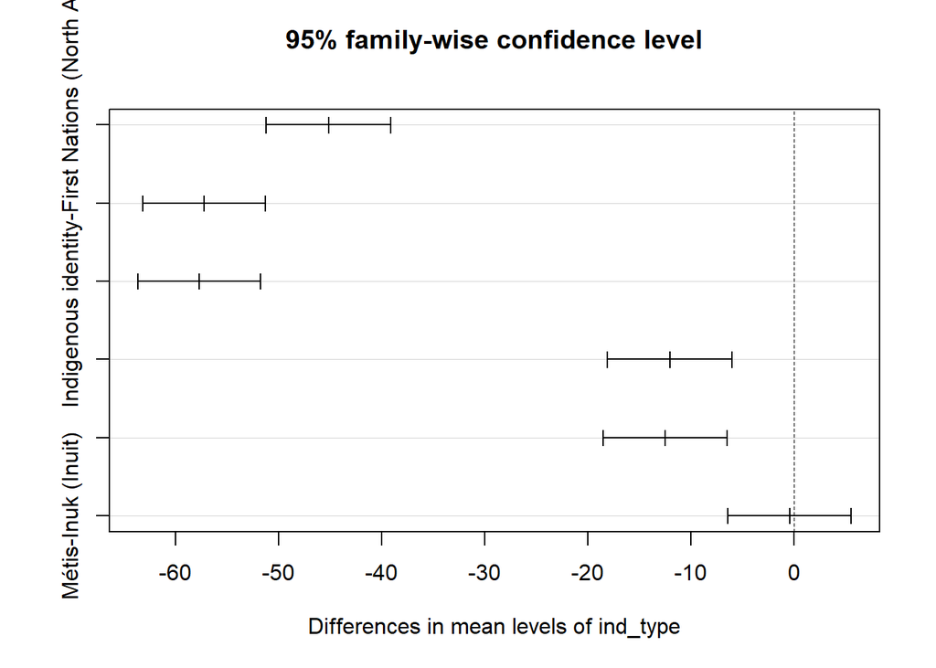

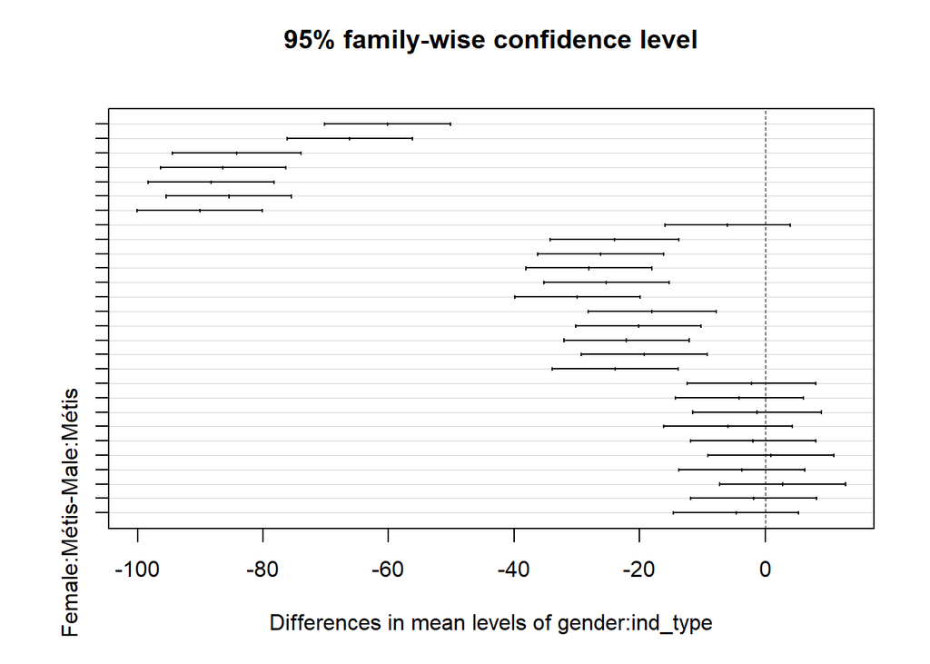

```r
plot(tukey_ID_nb)
```

Tukey HSD results for Negative Binomial model are identical to the Tukey HSD results for the Poisson model above.

```r
#Running Gaussian general linear model for "Log_victims" in df_age for "year", "age", "gender", and the interaction between "age" and "gender"
model_age_gaussian <- glm(Log_victims ~ year + age * gender, data = df_age, family = gaussian())
summary(model_age_gaussian)
```

```
##
## Call:
## glm(formula = Log_victims ~ year + age * gender, family = gaussian(),
##     data = df_age)
##
## Coefficients:
##                                     Estimate Std. Error t value Pr(>|t|)
## (Intercept)                       -1.852e+00  5.477e-01  -3.381 0.000913 ***
## year                               1.636e-04  2.949e-05   5.550 1.20e-07 ***
## age12 to 17 years                  6.658e-01  1.905e-01   3.495 0.000616 ***
## age18 to 24 years                  2.019e+00  1.905e-01  10.601  < 2e-16 ***
## age25 to 29 years                  1.937e+00  1.905e-01  10.168  < 2e-16 ***
## age30 to 39 years                  2.520e+00  1.905e-01  13.229  < 2e-16 ***
## age40 to 49 years                  1.889e+00  1.905e-01   9.916  < 2e-16 ***
## age50 to 59 years                  1.254e+00  1.905e-01   6.583 6.65e-10 ***
## age60 years and over               5.393e-01  1.905e-01   2.831 0.005245 **
## genderFemale                       2.212e-02  1.905e-01   0.116 0.907690
## age12 to 17 years:genderFemale    -8.111e-01  2.727e-01  -2.974 0.003409 **
## age18 to 24 years:genderFemale    -1.106e+00  2.694e-01  -4.106 6.48e-05 ***
## age25 to 29 years:genderFemale    -1.264e+00  2.694e-01  -4.693 5.85e-06 ***
## age30 to 39 years:genderFemale    -1.199e+00  2.694e-01  -4.451 1.62e-05 ***
## age40 to 49 years:genderFemale    -1.189e+00  2.694e-01  -4.414 1.89e-05 ***
## age50 to 59 years:genderFemale    -1.141e+00  2.768e-01  -4.121 6.11e-05 ***
## age60 years and over:genderFemale -1.230e+00  2.694e-01  -4.567 9.97e-06 ***
## ---
## Signif. codes:  0 '***' 0.001 '**' 0.01 '*' 0.05 '.' 0.1 ' ' 1
##
## (Dispersion parameter for gaussian family taken to be 0.19955)
##
##     Null deviance: 169.13  on 172  degrees of freedom
## Residual deviance:  31.13  on 156  degrees of freedom
## AIC: 230.24
##
## Number of Fisher Scoring iterations: 2
```

Residual deviance ratio: 0.184 (Low value suggests good fit) Calculated residual deviance: 0.2 (Value below 1 suggests possible under-dispersion) AIC: 230.24

```r
#Checking and plotting Pearson residuals and associated Quantile-Quantile (Q-Q) residuals
summary(residuals(model_age_gaussian, type = "pearson"))
```

```
##     Min.  1st Qu.   Median     Mean  3rd Qu.     Max.
## -1.60994 -0.19903  0.04775  0.00000  0.27447  0.85145
```

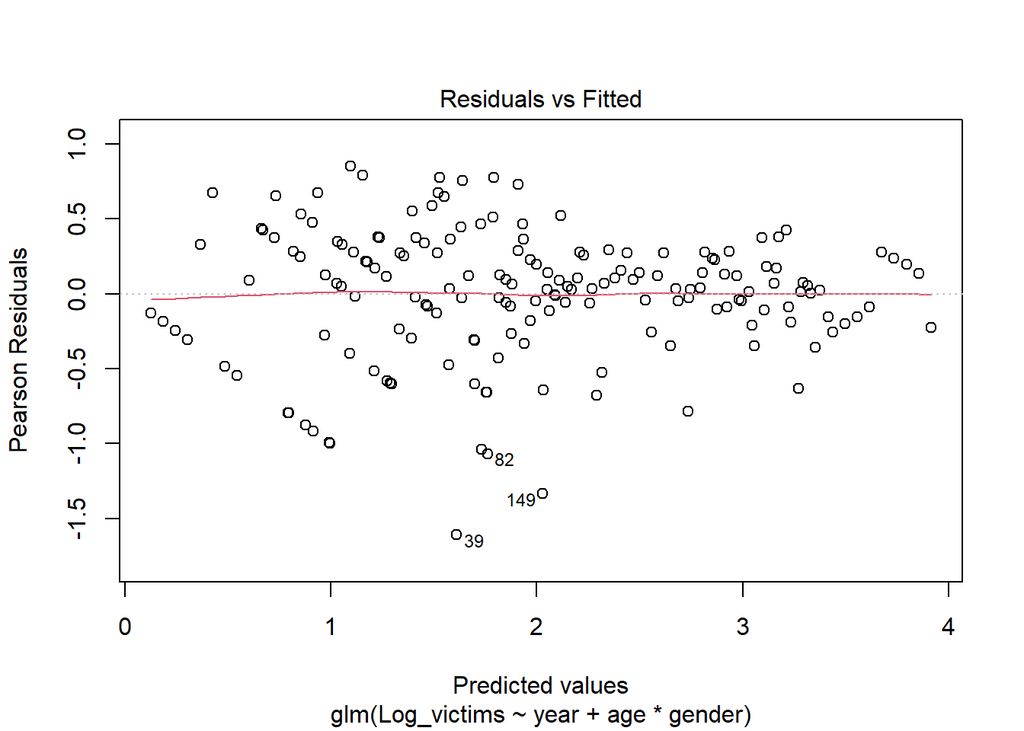

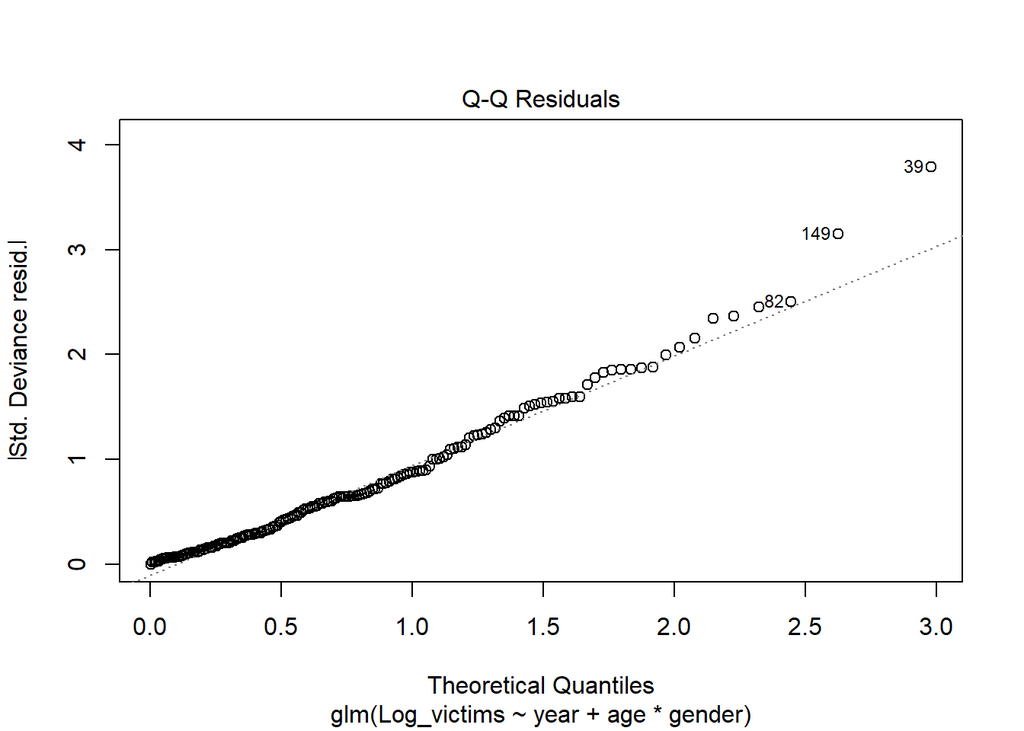

```r
plot(model_age_gaussian, which = 1:2)
```

Pearson residuals suggest a decent fit with a mean exactly at 0 and a closely symmetrical median at 0.0478. Residuals are asymmetric with a slight skew toward the left (−1.61 to +0.85) but not enough to invalidate inference. Furthermore, no significant outliers were found as the range still fits within acceptable parameters (±2).

Although the Gaussian model has the lowest AIC score, the under dispersion indicates the data’s variance is lower than its mean, which violates Gaussian assumptions, thus making the Gaussian model invalid.

```r
#Running Poisson general linear model for "victims" in df_age for "year", "age", "gender", and the interaction between "age" and "gender"
model_age_poisson <- glm(victims ~ year + age * gender, data = df_age, family = poisson())
summary(model_age_poisson)
```

```
##
## Call:
## glm(formula = victims ~ year + age * gender, family = poisson(),
##     data = df_age)
##
## Coefficients:
##                                     Estimate Std. Error z value Pr(>|z|)
## (Intercept)                       -1.447e+00  3.948e-01  -3.666 0.000246 ***
## year                               1.499e-04  1.983e-05   7.560 4.04e-14 ***
## age12 to 17 years                  5.991e-01  1.993e-01   3.006 0.002647 **
## age18 to 24 years                  1.878e+00  1.719e-01  10.921  < 2e-16 ***
## age25 to 29 years                  1.846e+00  1.723e-01  10.713  < 2e-16 ***
## age30 to 39 years                  2.393e+00  1.673e-01  14.307  < 2e-16 ***
## age40 to 49 years                  1.739e+00  1.736e-01  10.017  < 2e-16 ***
## age50 to 59 years                  1.124e+00  1.843e-01   6.098 1.08e-09 ***
## age60 years and over               4.473e-01  2.050e-01   2.182 0.029125 *
## genderFemale                      -7.350e-10  2.265e-01   0.000 1.000000
## age12 to 17 years:genderFemale    -8.189e-01  3.179e-01  -2.576 0.010001 *
## age18 to 24 years:genderFemale    -9.874e-01  2.564e-01  -3.851 0.000117 ***
## age25 to 29 years:genderFemale    -1.153e+00  2.611e-01  -4.415 1.01e-05 ***
## age30 to 39 years:genderFemale    -1.174e+00  2.474e-01  -4.746 2.08e-06 ***
## age40 to 49 years:genderFemale    -1.099e+00  2.632e-01  -4.173 3.00e-05 ***
## age50 to 59 years:genderFemale    -9.926e-01  2.944e-01  -3.372 0.000746 ***
## age60 years and over:genderFemale -1.166e+00  3.469e-01  -3.363 0.000771 ***
## ---
## Signif. codes:  0 '***' 0.001 '**' 0.01 '*' 0.05 '.' 0.1 ' ' 1
##
## (Dispersion parameter for poisson family taken to be 1)
##
##     Null deviance: 1502.92  on 172  degrees of freedom
## Residual deviance:  171.05  on 156  degrees of freedom
## AIC: 871.39
##
## Number of Fisher Scoring iterations: 4
```

Residual deviance ratio: 0.114 (Low value suggests good fit) Calculated residual deviance: 1.1 (Value above 1 suggests possible over-dispersion) AIC: 871.39

```r
#Checking and plotting Pearson residuals and associated Quantile-Quantile (Q-Q) residuals
summary(residuals(model_age_poisson, type = "pearson"))
```

```
##      Min.   1st Qu.    Median      Mean   3rd Qu.      Max.
## -2.579435 -0.646339 -0.060763  0.001173  0.594260  2.358266
```

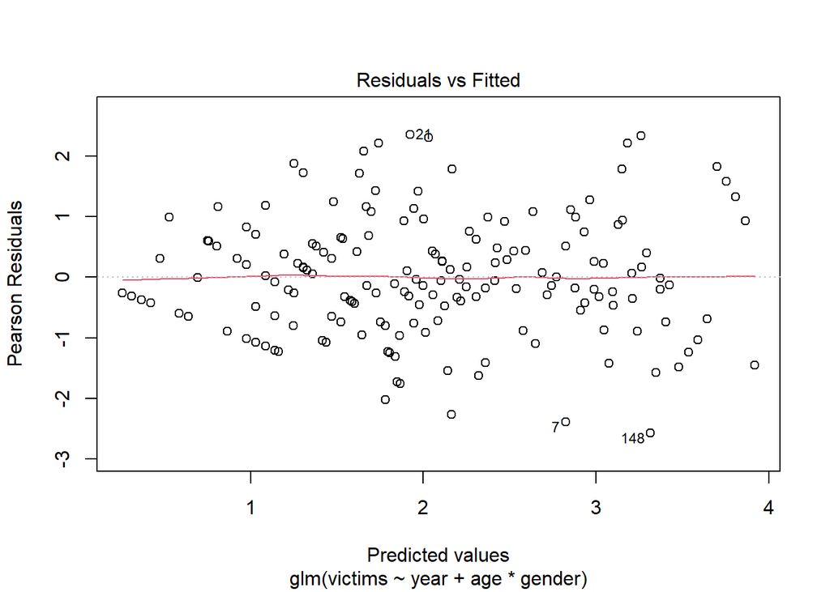

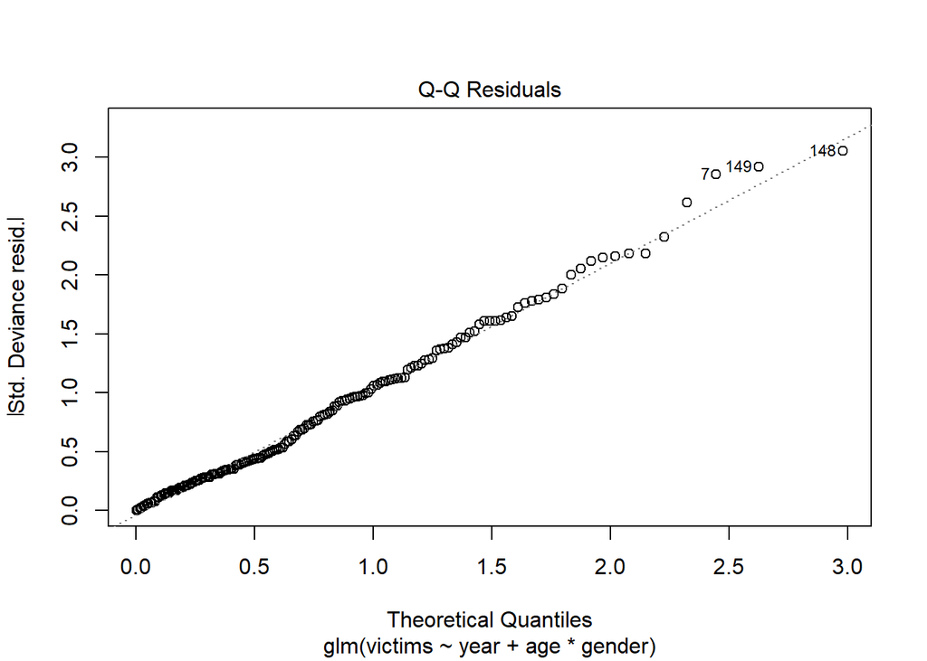

```r
plot(model_age_poisson, which = 1:2)
```

```r
#Checking and plotting Deviance residuals and associated Quantile-Quantile (Q-Q) residuals
summary(residuals(model_age_poisson, type = "deviance"))
```

```
##     Min.  1st Qu.   Median     Mean  3rd Qu.     Max.
## -2.85152 -0.68497 -0.06098 -0.05771  0.55956  2.18571
```

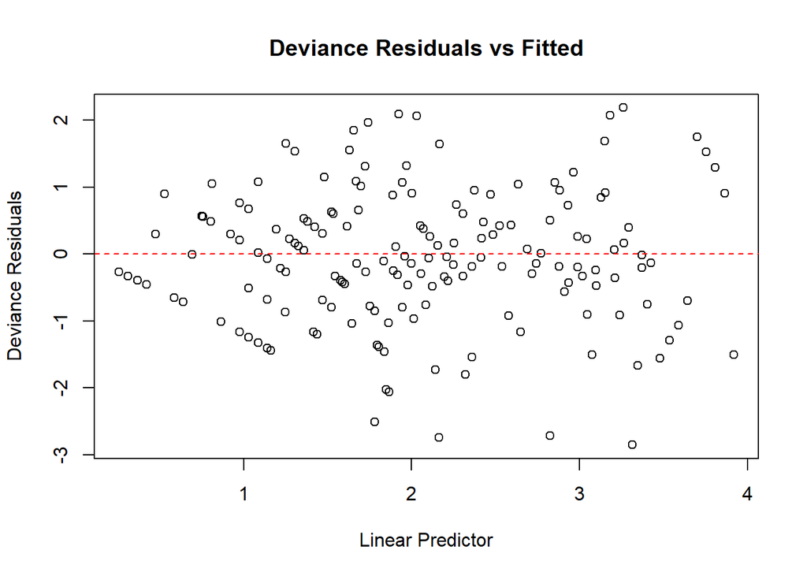

```r
dev_resid <- residuals(model_age_poisson, type = "deviance")
plot(predict(model_age_poisson, type = "link"), dev_resid,
     xlab = "Linear Predictor", ylab = "Deviance Residuals",
     main = "Deviance Residuals vs Fitted")
abline(h = 0, lty = 2, col = "red")
```

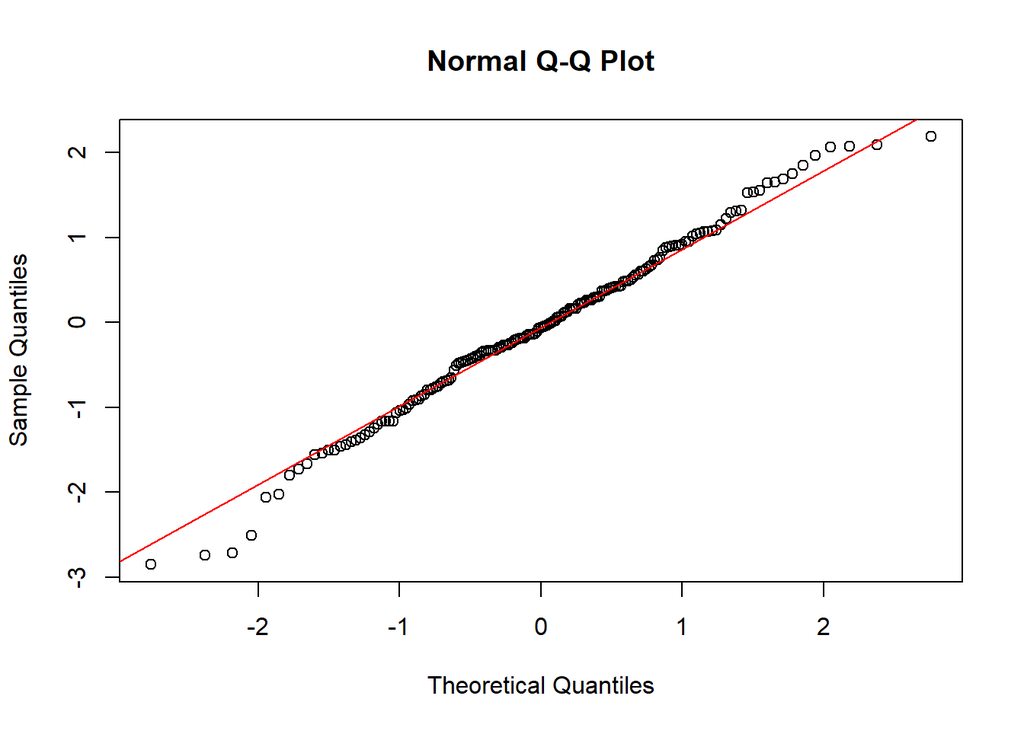

```r
qqnorm(dev_resid)
qqline(dev_resid, col = "red")
```

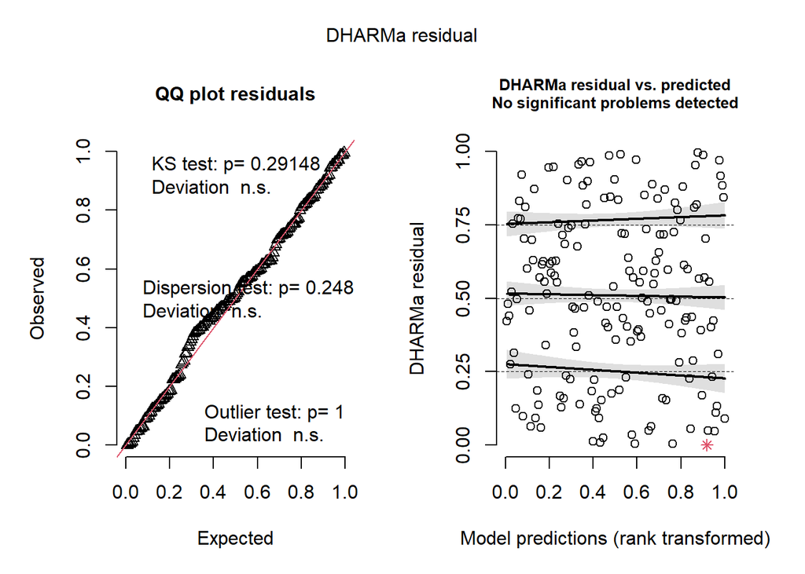

```r
#Plotting DHARMa Quantile residuals
plot(simulateResiduals(model_age_poisson))
```

Pearson residuals suggest a decent fit with a mean and median close to zero. Observations 7, 148, and 149 are highlighted as potential outliers. The slight deviation in the upper tail of the Q-Q plot also suggests these observations may be outliers. The range (−2.58, 2.36) falls just outside the the ±2 parameters at both tails suggesting minor over-dispersion.

DHARMa Quantile residuals suggest that the Poisson model fits our data well. With a non-significant KS test (p = 0.291) the observations follow the expected distribution. Non-significant p values for both the dispersion (p = 0.248) and outlier (P=1) tests suggest that there is neither significant over-dispersion or outliers in the model.

```r
#Running Negative Binomial general linear model for "victims" in df_age for "year", "age", "gender", and the interaction between "age" and "gender"
model_age_nb <- glm.nb(victims ~year + age * gender, data = df_age)
summary(model_age_nb)
```

```
##
## Call:
## glm.nb(formula = victims ~ year + age * gender, data = df_age,
##     init.theta = 150.5116766, link = log)
##
## Coefficients:
##                                     Estimate Std. Error z value Pr(>|z|)
## (Intercept)                       -1.433e+00  4.158e-01  -3.446 0.000569 ***
## year                               1.491e-04  2.104e-05   7.085 1.40e-12 ***
## age12 to 17 years                  5.998e-01  2.023e-01   2.964 0.003034 **
## age18 to 24 years                  1.879e+00  1.755e-01  10.711  < 2e-16 ***
## age25 to 29 years                  1.845e+00  1.759e-01  10.492  < 2e-16 ***
## age30 to 39 years                  2.391e+00  1.709e-01  13.986  < 2e-16 ***
## age40 to 49 years                  1.739e+00  1.771e-01   9.817  < 2e-16 ***
## age50 to 59 years                  1.124e+00  1.876e-01   5.991 2.09e-09 ***
## age60 years and over               4.473e-01  2.080e-01   2.151 0.031502 *
## genderFemale                      -6.266e-04  2.292e-01  -0.003 0.997818
## age12 to 17 years:genderFemale    -8.189e-01  3.219e-01  -2.544 0.010957 *
## age18 to 24 years:genderFemale    -9.884e-01  2.612e-01  -3.785 0.000154 ***
## age25 to 29 years:genderFemale    -1.150e+00  2.657e-01  -4.328 1.50e-05 ***
## age30 to 39 years:genderFemale    -1.172e+00  2.524e-01  -4.643 3.43e-06 ***
## age40 to 49 years:genderFemale    -1.099e+00  2.680e-01  -4.103 4.08e-05 ***
## age50 to 59 years:genderFemale    -9.933e-01  2.988e-01  -3.324 0.000887 ***
## age60 years and over:genderFemale -1.166e+00  3.504e-01  -3.329 0.000873 ***
## ---
## Signif. codes:  0 '***' 0.001 '**' 0.01 '*' 0.05 '.' 0.1 ' ' 1
##
## (Dispersion parameter for Negative Binomial(150.5117) family taken to be 1)
##
##     Null deviance: 1381.7  on 172  degrees of freedom
## Residual deviance:  158.0  on 156  degrees of freedom
## AIC: 872.46
##
## Number of Fisher Scoring iterations: 1
##
##
##               Theta:  151
##           Std. Err.:  175
##
##  2 x log-likelihood:  -836.456
```

Residual deviance ratio: 0.114 (Low value suggests good fit) Calculated residual deviance: 1.01 (Value extremely close to 1 suggests dispersion is properly addressed) AIC: 872.46

```r
#Checking and plotting Pearson residuals and associated Quantile-Quantile (Q-Q) residuals
summary(residuals(model_age_nb, type = "pearson"))
```

```
##      Min.   1st Qu.    Median      Mean   3rd Qu.      Max.
## -2.366383 -0.631373 -0.064704  0.001038  0.586490  2.300617
```